# 06 Simple Statistical Tests

31 August, 2018

## Overview

## Lesson Structure

In this session, we will cover unifactorial tests with only 2 levels in a factor.

Specifically, we'll cover:

- correlations
- one-sample, paired, and independent *t*-tests
- one-way ANOVA
- simple linear regression

This session assumes some experience with basic statistics.

## Getting Started

As always, we first need to load the `tidyverse` set of packages for this Chapter.

```r
library(tidyverse)
```

## Correlation

Is there a significant relationship between some observed variables?

### Background

**Variance**: Average of the squared differences from the mean (how much spread)

**Covariance**: Like variance, but not variation within observations, but how variables vary together; big number = related

**Correlation coefficient**: Standardised covariance (i.e. not sensitive to scale), bounded between -1 and 1. 0 is no relationship, -1/1 perfect relationship.

## Correlation: Real Data

Load data from the **OSL** (this code is in your Rmd file).

```r
# variables
scale_max <- 6
id <- "0Bz-rhZ21ShvOMGxnYUJfYmR5d2M" # google file ID
# load and clean data
corr_data <- read_csv(
  sprintf(
    "https://docs.google.com/uc?id=%s&export=download",
    id)
  ) %>%
  mutate(redist2 = (scale_max + 1) - redist2,
         redist4 = (scale_max + 1) - redist4) %>%
  transmute(PS,
            Fair_Satisfied = (fairness + satisfaction) / 2,
            Support = (redist1 + redist2 + redist3 + redist4) / 4
            ) %>%
  rename_all(tolower)
corr_data
```

```
## # A tibble: 305 x 3
##       ps fair_satisfied support
##    <int>          <dbl>   <dbl>
##  1   233            1      5.5
##  2   157            3.5    3.25
##  3   275            5      3.75
##  4   111            7      2.75
##  5    52            4.5    3
##  6    11            2.5    3.75
##  7    76            3      4.25
##  8    90            4.5    3.5
##  9    93            4      3.75
## 10   104            4.5    3.5
## # ... with 295 more rows
```

## Correlation: Real Data

- `sprintf()` replaces the %s with the URL stored in `id`.
- in `mutate()` we change the reverse scored items to be on the same scale
- then keep mean scores for our variables with participant number, and rename all to lowercase

```
## # A tibble: 6 x 3
##      ps fair_satisfied support
##   <int>          <dbl>   <dbl>
## 1   233            1      5.5
## 2   157            3.5    3.25
## 3   275            5      3.75
## 4   111            7      2.75
## 5    52            4.5    3
## 6    11            2.5    3.75
```

## Correlation: Real Data

We predicted those who see society as fair, and are satisfied with the status quo will have less support for redistribution of wealth.

Calculate means and standard deviations for our variables. We use `summarise_at()`, a variant on summarise for this.

- must define vars, or functions to perform summary.

```r
corr_data %>% summarise_at(c("fair_satisfied", "support"),
                           vars(mean, sd)
                           )
```

```
## # A tibble: 1 x 4
##   fair_satisfied_mean support_mean fair_satisfied_sd support_sd
##                 <dbl>        <dbl>             <dbl>      <dbl>
## 1                3.54         3.91              2.02       1.15
```

## Correlation: Assumptions

- variables are linearly related
- variables follow a normal distribution (**assumption of normality**)

2 options

1. QQ-plot for visual inspection of normality
2. Shapiro-Wilk test for statistical evaluation of normality

## Correlation: Assumptions

### QQ-plots

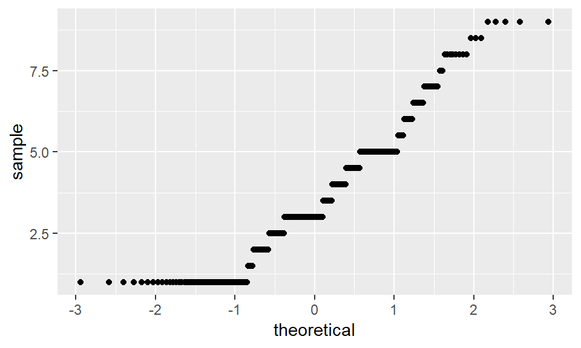

```r
corr_data %>%
  ggplot(aes(sample = fair_satisfied)) +
    geom_qq()
```

## Correlation: Assumptions

### QQ-plots

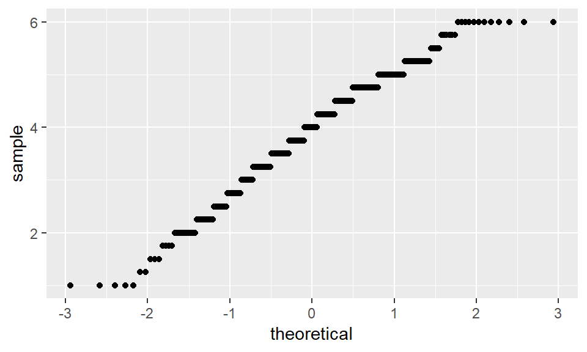

```r
corr_data %>%
  ggplot(aes(sample = support)) +
    geom_qq()
```

## Correlation: Assumptions

### Shapiro-Wilk

Significant results indicate the assumption of normality is **violated**

```r
shapiro.test(corr_data$fair_satisfied)
```

```
##
##  Shapiro-Wilk normality test
##
## data:  corr_data$fair_satisfied
## W = 0.92602, p-value = 3.697e-11
```

## Correlation: Assumptions

### Shapiro-Wilk

Significant results indicate the assumption of normality is **violated**

```r
shapiro.test(corr_data$support)
```

```
##
##  Shapiro-Wilk normality test
##
## data:  corr_data$support
## W = 0.97622, p-value = 5.993e-05
```

## Running a Correlation

- We use `cor.test()`, which takes as an argument two columns from a data.frame or matrix, which are your two factors to compare
- Produces test statistics, including *t*-values, *p*-values, and 95% confidence intervals
- Defaults to Pearson's R (parametric data), and to a two-sided test of significance (no predicted direction of effect)

## Running a Correlation

- Our data violate test assumptions, so we can use a **non-parametric** alternative to Pearson's R, Kendall's Tau.
- We predicted a negative correlation between `fair_satisfied` and `support`, so alternative hypothesis is "less"

## Running a Correlation

```r
cor.test(corr_data$fair_satisfied, corr_data$support,
         method = "kendall",
         alternative = "less"
         )
```

```
##
##  Kendall's rank correlation tau
##
## data:  corr_data$fair_satisfied and corr_data$support
## z = -13.157, p-value < 2.2e-16
## alternative hypothesis: true tau is less than 0
## sample estimates:
##        tau
## -0.5473132
```

## Running a Correlation

- We found a signficiant negative relationship at \(\alpha\) threshold of 0.05
- *p*-value: assuming null hypothesis, and in the long run, probability of observing as large or larger effects
- But don't mindlessly choose \(\alpha\)!
- Can square Pearson's R for \(R^2\), which tells you how change in 1 variable affects another.

## *t*-tests

## *t*-tests

- Do two means differ?
- Get *t*- and *p*- values
- *t*-value: ratio of difference between groups of scores vs. difference within groups. Larger = difference between groups is large.

## *t*-tests

We'll use the lexdec data set, excluding the fake subjects we put in there last time.

```r
lexdec <- read_csv("inputs/lexical_decision_raw_data.csv") %>%
  filter(!subject %in% (as.character(22:30)))
```

## One-sample *t*-test

- Compare group mean against a reference mean value
- e.g. do the frequencies of words in our study differ to 4 (presumed mean in the population)?

Aggregate the data by word id!

```r
lexdec_onesamp <- lexdec %>%
  group_by(word) %>%
  summarise(freq = mean(frequency))
```

## One-sample *t*-test

Use the `t.test()` function. Takes your scores as one argument, and population mean as another (\(\mu\); pronounced mu)

```r
t.test(lexdec_onesamp$freq, mu = 4)
```

```
##
##  One Sample t-test
##
## data:  lexdec_onesamp$freq
## t = 5.2044, df = 78, p-value = 1.535e-06
## alternative hypothesis: true mean is not equal to 4
## 95 percent confidence interval:
##  4.463784 5.038436
## sample estimates:
## mean of x
##   4.75111
```

## One-sample *t*-test

We get:

- *t* and *p* values
- and 95% confidence interval
- *Note*: 95% CI: 95% of your confidence intervals will contain the true value in the long run

## Independent-Samples *t*-test

- Comparing two means across groups
- e.g. does the native language of the speaker, English or "other", have any impact on reaction times to the task?

### Prepare Data

```r
lexdec_ind <- lexdec %>%
  group_by(subject, native_language) %>%
  summarise(log_RT = mean(log(RT), na.rm = T))
```

## Independent-Samples *t*-test

### Calculate Descriptives

```r
lexdec_ind %>%
  group_by(native_language) %>%
  summarise(mean_log_RT = mean(log_RT, na.rm = T),
            sd_log_RT = sd(log_RT, na.rm = T),
            n = n())
```

```
## # A tibble: 2 x 4
##   native_language mean_log_RT sd_log_RT     n
##   <chr>                 <dbl>     <dbl> <int>
## 1 English                6.33    0.0982    11
## 2 Other                  6.47    0.178      9
```

## Independent-Samples *t*-test

Use formula syntax if data is in long format.

The thing on the left is a function of the thing on the right.

`dependent variable ~ group variable, data = data source`

## Independent-Samples *t*-test

```r
t.test(log_RT ~ native_language, data = lexdec_ind, paired = FALSE)
```

```
##
##  Welch Two Sample t-test
##
## data:  log_RT by native_language
## t = -2.2213, df = 11.903, p-value = 0.0465
## alternative hypothesis: true difference in means is not equal to 0
## 95 percent confidence interval:
##  -0.29139463 -0.00268428
## sample estimates:
## mean in group English   mean in group Other
##              6.326837              6.473876
```

## Checking *t*-test asssumptions

- Homogeneity of Variance: variance is similar across samples.
- For parametric data, use `bartlett.test()`, for non-parametric use `fligner.test()`
- Significant results = assumption is **violated**

```r
bartlett.test(log_RT ~ native_language, data = lexdec_ind)
```

```
##
##  Bartlett test of homogeneity of variances
##
## data:  log_RT by native_language
## Bartlett's K-squared = 2.9197, df = 1, p-value = 0.08751
```

We're safe!

## Paired-Samples *t*-test

Simulate some data, this code is done for you in your class script Rmd file.

```r
set.seed(1000)
stroop_dat <- tibble(
  subject = seq(1:60),
  congruent = rnorm(mean = 400, sd = 30, n = 60),
  incongruent = congruent + rnorm(mean = 30, sd = 10, n = 60)
  ) %>%
  gather(key = condition, value = reaction_time, 2:3) %>%
  mutate(
    log_RT = log(reaction_time)
  )
```

## Paired-Samples *t*-test

Simulate some data, this code is done for you in your class script Rmd file.

```r
stroop_dat
```

```
## # A tibble: 120 x 4
##    subject condition reaction_time log_RT
##      <int> <chr>             <dbl>  <dbl>
##  1       1 congruent          387.   5.96
##  2       2 congruent          364.   5.90
##  3       3 congruent          401.   5.99
##  4       4 congruent          419.   6.04
##  5       5 congruent          376.   5.93
##  6       6 congruent          388.   5.96
##  7       7 congruent          386.   5.96
##  8       8 congruent          422.   6.04
##  9       9 congruent          399.   5.99
## 10      10 congruent          359.   5.88
## # ... with 110 more rows
```

## Paired-Samples *t*-test

If not in long format, we can do this:

```r
t.test(data$dependent_variable_one,
       data$dependent_variable_two,
       data = data_name,
       paired = TRUE
       )
```

## Paired-Samples *t*-test

But it is long format, so we'll do this:

```r
t.test(log_RT ~ condition, data = stroop_dat, paired = TRUE)
```

```
##
##  Paired t-test
##
## data:  log_RT by condition
## t = -25.573, df = 59, p-value < 2.2e-16
## alternative hypothesis: true difference in means is not equal to 0
## 95 percent confidence interval:
##  -0.08379794 -0.07163601
## sample estimates:
## mean of the differences
##             -0.07771698
```

## ANOVA

## ANOVA

- F-statistic: the ratio of the variance between two samples
- Larger F-statistic, greater variance between samples
- `aov()` function used for **a**nalysis **o**f **v**ariance

## ANOVA: One-way Independent Samples

Use the same data as for the *t*-test

```r
anova_ind <- aov(log_RT ~ native_language, data = lexdec_ind)
summary(anova_ind)
```

```
##                 Df Sum Sq Mean Sq F value Pr(>F)
## native_language  1 0.1070 0.10702   5.523 0.0304 *
## Residuals       18 0.3488 0.01938
## ---
## Signif. codes:  0 '***' 0.001 '**' 0.01 '*' 0.05 '.' 0.1 ' ' 1
```

## ANOVA: One-way Paired-Samples

- Specify our models as before, but include an error term.
- This error term takes the form of:

`Error(observation unit/grouping factor)`

Read this as your observational units are within your groups.

## ANOVA: One-way Paired-Samples

Use the same data as for the *t*-test

```r
anova_paired <- aov(log_RT ~ condition + Error(subject/condition), data = stroop_dat)
summary(anova_paired)
```

```
##
## Error: subject
##           Df   Sum Sq  Mean Sq F value Pr(>F)
## Residuals  1 0.005198 0.005198
##
## Error: subject:condition
##           Df Sum Sq Mean Sq
## condition  1 0.1359  0.1359
##
## Error: Within
##            Df Sum Sq Mean Sq F value  Pr(>F)
## condition   1 0.0453 0.04535   8.302 0.00472 **
## Residuals 116 0.6336 0.00546
## ---
## Signif. codes:  0 '***' 0.001 '**' 0.01 '*' 0.05 '.' 0.1 ' ' 1
```

## Linear Regression

## Linear Regression

- Predict a linear relationship between one or more variable(s) and a continuous dependent variable
- Predictor variables can be continuous or categorical

General form:

\[Y = \beta_0 + \beta_1X + e\] - Outcome = intercept + slope \(\times\) condition effect + residual error - *Note*: We do not fit a perfect model, hence error term - Residuals = distance of observed values from predicted values

## Independent Samples

Same data as before.

```r
lm_ind <- lm(log_RT ~ native_language, data = lexdec_ind)
summary(lm_ind)
```

```
##
## Call:
## lm(formula = log_RT ~ native_language, data = lexdec_ind)
##
## Residuals:
##      Min       1Q   Median       3Q      Max
## -0.22075 -0.07276 -0.00893  0.07599  0.33469
##
## Coefficients:
##                      Estimate Std. Error t value Pr(>|t|)
## (Intercept)           6.32684    0.04197  150.75   <2e-16 ***
## native_languageOther  0.14704    0.06256    2.35   0.0304 *
## ---
## Signif. codes:  0 '***' 0.001 '**' 0.01 '*' 0.05 '.' 0.1 ' ' 1
##
## Residual standard error: 0.1392 on 18 degrees of freedom
## Multiple R-squared:  0.2348, Adjusted R-squared:  0.1923
## F-statistic: 5.523 on 1 and 18 DF,  p-value: 0.03037
```

## Independent Samples

```r
lexdec_means <- lexdec_ind %>%
  group_by(native_language) %>%
  summarise(mean = mean(log_RT))
lexdec_means
```

```
## # A tibble: 2 x 2
##   native_language  mean
##   <chr>           <dbl>
## 1 English          6.33
## 2 Other            6.47
```

How do these means relate to the intercept and slope?

## Independent Samples

How do these means relate to the intercept and slope?

```r
lexdec_means$mean[2] - lexdec_means$mean[1]
```

```
## [1] 0.1470395
```

```r
lm_ind$coefficients
```

```
##          (Intercept) native_languageOther
##            6.3268366            0.1470395
```

## Paired Samples

Same data as before. Same interpretation as with independent samples. No need for an error term.

```r
lm_pair <- lm(log_RT ~ condition, data = stroop_dat)
summary(lm_pair)
```

```
##
## Call:
## lm(formula = log_RT ~ condition, data = stroop_dat)
##
## Residuals:
##       Min        1Q    Median        3Q       Max
## -0.153786 -0.049960  0.006172  0.039194  0.202953
##
## Coefficients:
##                      Estimate Std. Error t value Pr(>|t|)
## (Intercept)          5.978613   0.009499 629.391  < 2e-16 ***
## conditionincongruent 0.077717   0.013434   5.785 6.07e-08 ***
## ---
## Signif. codes:  0 '***' 0.001 '**' 0.01 '*' 0.05 '.' 0.1 ' ' 1
##
## Residual standard error: 0.07358 on 118 degrees of freedom
## Multiple R-squared:  0.221,  Adjusted R-squared:  0.2144
## F-statistic: 33.47 on 1 and 118 DF,  p-value: 6.066e-08
```

## Linear Regression Assumptions

Simple general linear models make a few assumptions, of which:

- Linear relationship: your variables must be linearly related
- Normality: Variables must be normally distributed
- Homoscedasticity (homogeneity of variance): your residuals are equal across the regression line
- No auto-correlation: your observations for your dependent variable must not impact one-another

## Generalised Linear Model

## Generalised Linear Model

- What if your data are not continuous? Use a generalised linear model
- These use a link function, which allows the dependent variable to be a function of some error term other than the normal distribution (e.g. logistic)

## Generalised Linear Model

Make some data, this is in your class script Rmd file.

```r
set.seed(1000)
prob <- rep(c(0.3, 0.6), 50)
cond <- rep(c("control", "intervention"), 50)
subject <- seq(1:100)

smoking_dat <- tibble(
  subject = subject,
  cond = cond,
  outcome = rbinom(n = 100, size = 1, prob = prob)
)
```

## Generalised Linear Model

Look at the descriptives for your new data.

```r
smoking_dat %>% group_by(cond) %>% summarise(mean = mean(outcome))
```

```
## # A tibble: 2 x 2
##   cond          mean
##   <chr>        <dbl>
## 1 control       0.24
## 2 intervention  0.54
```

## Generalised Linear Model

- Takes a similar form to the `lm()` but we use `glm()` and need to specify a family for our link function
- Here we specify the data come from a binomial distribution
- Now get z-scores instead of *t*-values

```r
glm_ind <- glm(outcome ~ cond, data = smoking_dat, family = "binomial")
```

## Generalised Linear Model

```r
summary(glm_ind)
```

```
##
## Call:
## glm(formula = outcome ~ cond, family = "binomial", data = smoking_dat)
##
## Deviance Residuals:
##     Min       1Q   Median       3Q      Max
## -1.2462  -0.7409  -0.7409   1.1101   1.6894
##
## Coefficients:
##                  Estimate Std. Error z value Pr(>|z|)
## (Intercept)       -1.1527     0.3311  -3.481   0.0005 ***
## condintervention   1.3130     0.4361   3.011   0.0026 **
## ---
## Signif. codes:  0 '***' 0.001 '**' 0.01 '*' 0.05 '.' 0.1 ' ' 1
##
## (Dispersion parameter for binomial family taken to be 1)
##
##     Null deviance: 133.75  on 99  degrees of freedom
## Residual deviance: 124.10  on 98  degrees of freedom
## AIC: 128.1
##
## Number of Fisher Scoring iterations: 4
```

## Proportion Data

- Again use the generalised linear model with the `glm()` function
- Need number of successed and observations from which successes are counted

Specify without pre-calculated proportions:

`glm(successes/observations ~ cond, data = smoking_dat, family = "binomial")`

Specify with pre-calculated proportions:

`glm(proportion ~ cond, data = smoking_dat, family = "binomial", weights = observations)`

Note you need to set weights as the observations that contributed in this latter form.